# Project 3 - Example Main Script

Chengliang Tang, Tian Zheng

In your final repo, there should be an R markdown file that organizes **all computational steps** for evaluating your proposed image classification framework.

This file is currently a template for running evaluation experiments of image analysis (or any predictive modeling). You should update it according to your codes but following precisely the same structure.

```r
if(!require("EBImage")){
  source("https://bioconductor.org/biocLite.R")
  biocLite("EBImage")
}
if(!require("gbm")){
  install.packages("gbm")
}
library("EBImage")
library("gbm")
```

### Step 0: specify directories.

Set the working directory to the image folder. Specify the training and the testing set. For data without an independent test/validation set, you need to create your own testing data by random subsampling. In order to obain reproducible results, set.seed() whenever randomization is used.

```r
set.seed(2018)
# use relative path for reproducibility
```

Provide directories for training images. Low-resolution (LR) image set and High-resolution (HR) image set will be in different subfolders.

```r
train_dir <- "../data/train/" # This will be modified for different data sets.
train_LR_dir <- paste(train_dir, "LR/", sep="")
train_HR_dir <- paste(train_dir, "HR/", sep="")
train_label_path <- paste(train_dir, "label.csv", sep="")
```

### Step 1: set up controls for evaluation experiments.

In this chunk, we have a set of controls for the evaluation experiments.

```r
K <- 5  # number of CV folds
```

### Step 2: import training images class labels.

We provide extra information of image label: car (0), flower (1), market (2). These labels are not necessary for your model.

```r
extra_label <- read.csv(train_label_path, colClasses=c("NULL", NA, NA))
```

### Step2.5 split the training/test set according to lables

```r
ts<-c()#index of test set
l<-unique(extra_label$Label)
label<-extra_label$Label
for(i in l){
  train_sub<-which(label==i)
  ts<-c(ts,sample(train_sub,length(train_sub)/5))
}
train_ind<-setdiff(1:1500,ts)#index of training set
```

### Step 3: construct features and responses

`feature.R` should be the wrapper for all your feature engineering functions and options. The function `feature( )` should have options that correspond to different scenarios for your project and produces an R object that contains features and responses that are required by all the models you are going to evaluate later. + `feature.R` + Input: a path for low-resolution images. + Input: a path for high-resolution images. + Output: an RData file that contains extracted features and corresponding responses

```r
source("../lib/feature.R")
tm_feature_train <- NA
if(run.feature.train){
  tm_feature_train <- system.time(dat_train <- feature(train_LR_dir, train_HR_dir,index=train_ind))
  feat_train <- dat_train$feature
  label_train <- dat_train$label
}
save(dat_train, file="../output/feature_train.RData")
```

```r
load("../output/feature_train.RData")
feat_train <- dat_train$feature
label_train <- dat_train$label
```

### Step 4: Train a regression model with training features and responses

Call the train model and test model from library.

`train.R` and `test.R` should be wrappers for all your model training steps and your classification/prediction steps. + `train.R` + Input: a path that points to the training set features and responses. + Output: an RData file that contains trained classifiers in the forms of R objects: models/settings/links to external trained configurations. + `test.R` + Input: a path that points to the test set features. + Input: an R object that contains a trained classifier. + Output: an R object of response predictions on the test set. If there are multiple classifiers under evaluation, there should be multiple sets of label predictions.

```r
source("../lib/train_lightGBM.R")
source("../lib/test_lightGBM.R")
```

#### Model selection with cross-validation

```r
source("../lib/cv_lightGBM.R")

lrseq <- seq(0.01, 0.2, 0.01)
err_cv_lgb <- cbind(lrseq, array(dim=c(length(lrseq), 2)))
colnames(err_cv_lgb) <- c("Learning Rate", "mean_cv_error", "sd_cv_error")
for (i in 1:length(lrseq)){
  err_cv_lgb[i,2:3] <- cv.lgb(dat_train$feature, dat_train$label, nr = 200,  lr = lrseq[i], K = 5)
}

save(err_cv_lgb, file="../output/err_cv_lgb_1.RData")
```

Visualize cross-validation results.

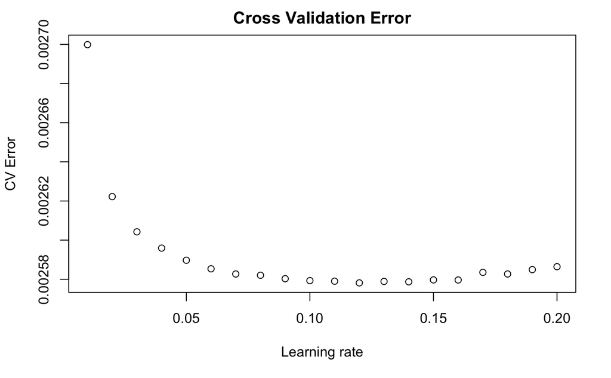

- Choose the “best”" parameter value

```r
lr_best <- err_cv_lgb[,1][which.min(err_cv_lgb[,2])]
nr_best <- 200
par_best_lgb <- list(nr=nr_best, lr = lr_best)
```

- Train the model with the entire training set using the selected model (model parameter) via cross-validation.

```r
tm_train_lgb=NA
tm_train_lgb <- system.time(fit_train <- train.lgb(feat_train, label_train, par_best_lgb))
```

[output not shown]

[output not shown]

### Step 5: Super-resolution for test images

Feed the final training model with the completely holdout testing data. + `superResolution.R` + Input: a path that points to the folder of low-resolution test images. + Input: a path that points to the folder (empty) of high-resolution test images. + Input: an R object that contains tuned predictors. + Output: construct high-resolution versions for each low-resolution test image.

```r
source("../lib/superResolution.R")
test_dir <- "../data/train/" # This will be modified for different data sets.
test_LR_dir <- paste(test_dir, "LR/", sep="")
test_HR_dir <- paste(test_dir, "HR/", sep="")
tm_test=NA
if(run.test){
  load(file="../output/fit_train.RData")
  tm_test <- system.time(performance<-superResolution(train_LR_dir, train_HR_dir,fit_train,index=ts))
}
```

### Summarize the test MSE and PSNR

```r
#test mse
performance[1]
#test psnr
performance[2]
```

[output not shown]

### Summarize Running Time

Prediction performance matters, so does the running times for constructing features and for training the model, especially when the computation resource is limited.

```r
cat("Time for constructing training features=", tm_feature_train[1], "s \n")
cat("Time for training model=", tm_train[1], "s \n")
cat("Time for super-resolution=", tm_test[1], "s \n")
```

[output not shown]